# Generates ggplots for (1) cosine index distribution across all possible pairwise industries (2) box and bar plots by comparing among different user-defined groups

What does the package do?

This R package generates ggplots for (1) cosine index distribution across all possible pairwise industries (2) box and bar plots by comparing among different user-defined groups.

# 1. Installing the package

`comparision` is available on Github and can be installed as follows in an R session:

```r
#install the devtools to download the R package from comparision repo in Github
install.packages('devtools', repos = "http://cran.us.r-project.org")
devtools::install_github("kitcatkai/comparision")
```

Once installed, the package can be loaded in a given R session using:

```r
#import comparision library
library('comparision')
```

# 2. Download an example dataset

To illustrate how the package works, we can download a sample of data from `u_egdata.base_job_tran_1step` base table and name it as `cos_group_100.csv`.

After preparing the data, we can call `load_cosine()` with the file directory and the column name for the cosine index.

```r
#set to your working directory
setwd("/Users/kaitan/comparision/")

#calling load_file function
cosine <- load_cosine("./cos_group_100.csv", field = 'cosine_similarity_group')
```

# 3. Plot histogram across all possible pairwise industries

The easiest way of visualizing the histogram across all possible pairwise industries is through `cosine$skills`

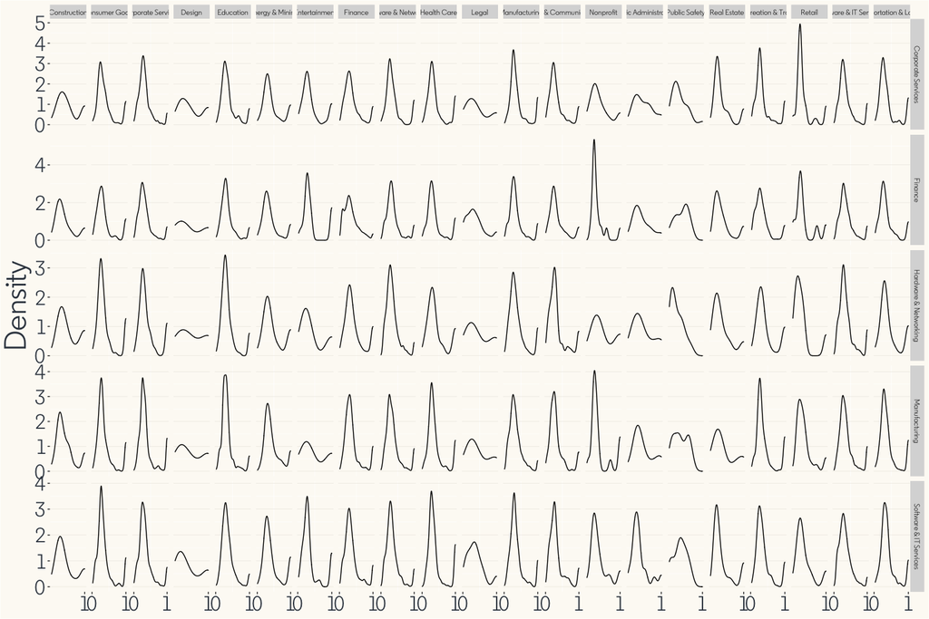

```r
#Plot histogram across all possible pairwise industries
cosine$skills
```

# 4. Generating ggplots by comparing among different user-defined groups

We can call `load_file()` with the file directory and the user-defined groups for `group_by`. Note that `load_file()` is different from the `load_cosine()`.

```r
setwd("/Users/kaitan/comparision/")

#calling load_file function
test <- load_file("./dummy_data.csv", group_by = 'age_bracket')
```

# 5(a) Plotting the box plot for the time it takes to transit to various industries by different age-bracket groups.

The easiest way of visualizing the box plot for the time it takes to transit to various industries by different age-bracket groups is `test$transit`. Remember that you can set you user-defined group in `group_by` as shown earlier.

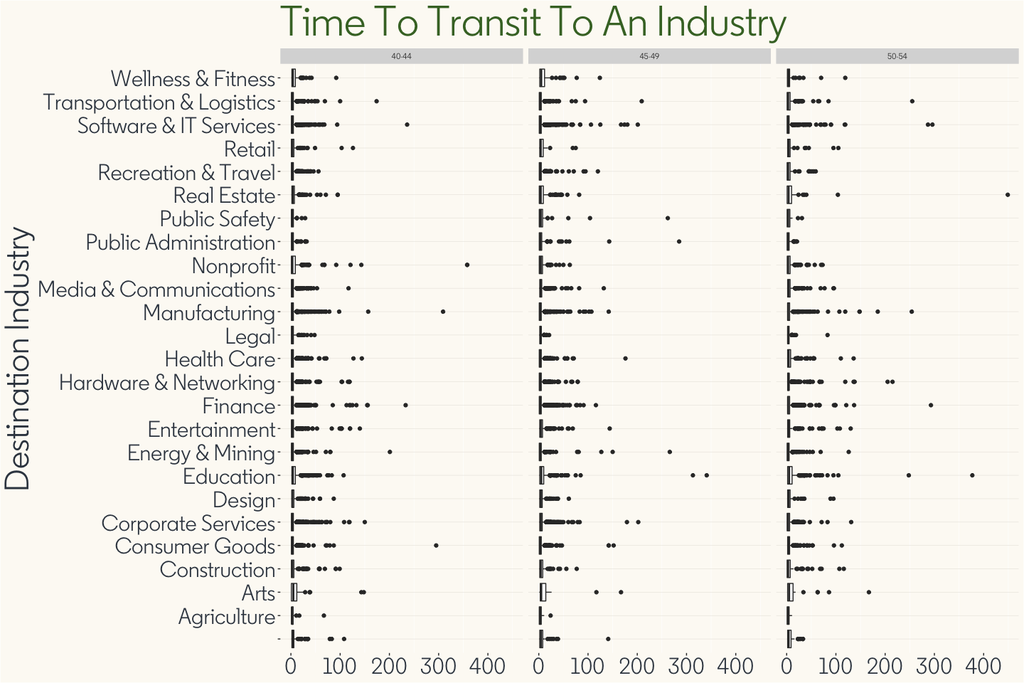

```r
#Plot Box plot for the time it takes to transit to various industries by different age-bracket groups
test$transit
```

# 5(b) Plotting the bar plot for the distribution of different age-bracket groups across various industries

The easiest way of visualizing bar plot for the distribution of different age-bracket groups across various industries is `test$demo`.

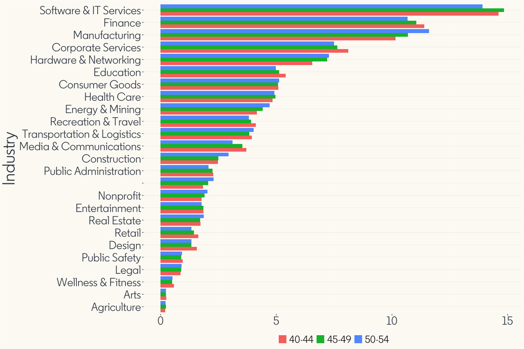

```r
#Bar plot for the distribution of different age-bracket groups across various industries
test$demo
```